# Lab 7 – Sampling Distribution and CLT

### `getSampleMean()`

Here, we introduce the `getSampleMean()` function. This function takes 3 arguments:

- `data` The dataset we wish to sample
- `variable` The name of the variable we want to sample
- `n` The number of observations we want in each sample

This function work similar to `sampleNormalData()` in that `n` tells us the sample size. However, instead of sampling from a normal distribution, we provide two other arguments: `data` tells us which dataset we wish to use and `variable` tells us which variable we want to sample and create a sample mean for.

For example, the following code collections 1000 samples from the variable `FourYearComp_Males`, each with 20 observations. It then returns a data.frame where each row includes the sample number as well as the mean for that sample

```r
## Sample from the variable FourYearComp_Males
df_males <- getSampleMean(college, FourYearComp_Males, n = 20)

## Example of first 10 rows
head(df_males, 10)
```

```
##       xbar sample
## 1  0.44626      1
## 2  0.45752      2
## 3  0.47678      3
## 4  0.42341      4
## 5  0.49308      5
## 6  0.54315      6
## 7  0.48093      7
## 8  0.48998      8
## 9  0.48464      9
## 10 0.46162     10
```

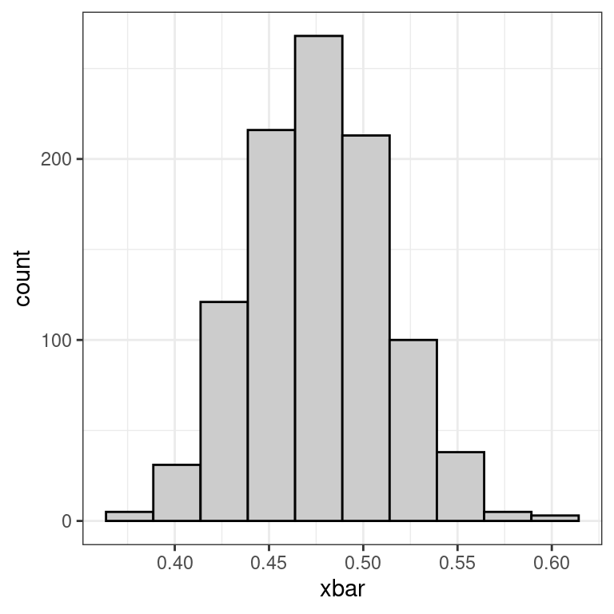

```r
## Plot distribution of xbar with gh()
ggplot(df_males, aes(xbar)) + gh(bins = 10)
```

This gives us an estimate of the *sampling distribution* for $\overline{x}$ from the four year completion rate of males when the sample size is $n = 20$.

### `simulateConfInt()`

Here, we introduce the `simulateConfInt()` function. This function takes 3 arguments:

- `n` Number of observations in sample
- `C` Multiplier for standard error, also called the *critical value*. This is the value that relates standard deviations to percentiles
- `sd` The population standard deviation

The function works by simulating the construction of 25 confidence intervals. The value `n` will determine the number of observations in our sample. The value for `C` determines the range of our confidence interval, as in the equation

$$\overline{x} \pm C \times \frac{\sigma}{\sqrt{n}}$$
Finally, `sd` determines the standard deviation from the population, $\sigma$.

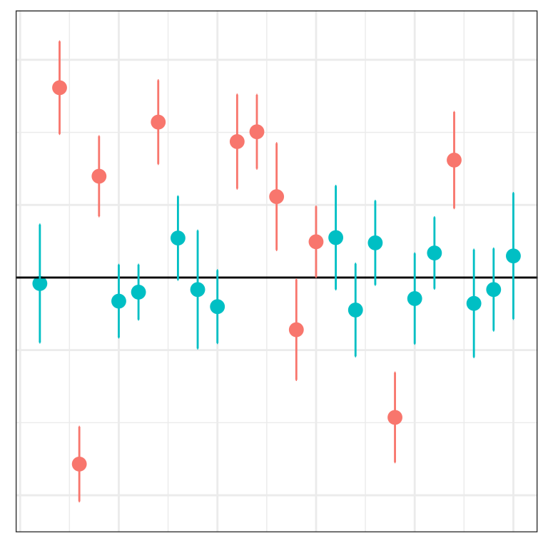

```r
simulateConfInt(n = 15, C = 0.5, sd = 50)
```

Although it will not be necessary, I will provide this illustration again here for reference. We can think of the $C$ term as being $C = 0, 1, 2, 3$ below (i.e., $\mu \pm C \times \sigma$) to give context for where these values should lie.

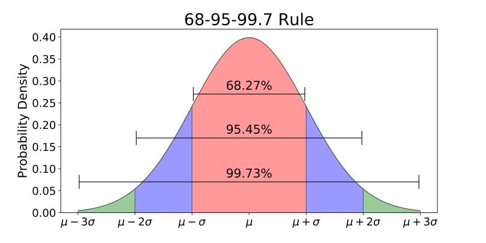

In a later lab, we will take the time to more directly associate percentiles with standard errors.